# Отчет по лабораторной работе №3

Адресация IPv4 и IPv6

Виноградова М.А

Российский университет дружбы народов, Москва, Россия

8 октября 2026

# Информация

## Докладчик

- Виноградова Мария Андреевна
- студентка НПИбд-02-24
- номер студ. билета 1132240691
- Российский университет дружбы народов
- 1132240691@pfur.ru
- https://github.com/mavinogradova/study_2026-2027

# Цель работы

Изучение принципов организации адресного пространства.

# Задание

1. Разбиение IPv4-сети на подсети:
   - Задана IPv4-сеть 172.16.20.0/24. Определить префикс, маску, broadcast-адрес, число возможных подсетей, диапазон адресов узлов. Разбить сеть на 3 подсети с максимально возможным числом адресов узлов 126, 62, 62 соответственно.
   - Задана сеть 10.10.1.64/26. Определить префикс, маску, broadcast-адрес, число возможных подсетей, диапазон адресов узлов. Выделить подсеть на 30 узлов.
   - Задана сеть 10.10.1.0/26. Определить префикс, маску, broadcast-адрес, число возможных подсетей, диапазон адресов узлов. Выделить подсеть на 14 узлов.
2. Разбиение IPv6-сети на подсети:
   - Задана сеть 2001:db8:c0de::/48. Охарактеризовать адрес, определить маску, префикс, краевые значения. Разбить на 2 подсети двумя способами — с использованием идентификатора подсети и с использованием идентификатора интерфейса.
   - Задана сеть 2a02:6b8::/64. Охарактеризовать адрес, определить маску, префикс, краевые значения. Разбить на 2 подсети двумя способами.

# Выполнение лабораторной работы

# IPv4. Задание 1. Сеть 172.16.20.0/24

## Расчёт подсети A (126 узлов)

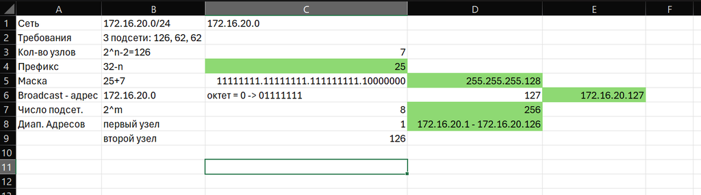

Расчёт подсети A (126 узлов) для сети 172.16.20.0/24

## Расчёт подсети B (62 узла)

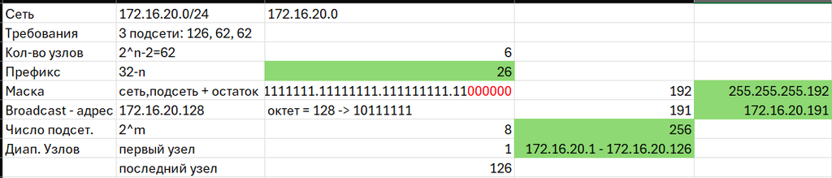

Расчёт подсети B (62 узла) для сети 172.16.20.0/24

## Расчёт подсети C (62 узла)

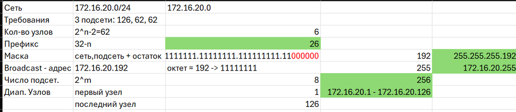

Расчёт подсети C (62 узла) для сети 172.16.20.0/24

## Итоговая таблица разбиения

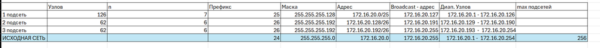

Итоговая таблица разбиения сети 172.16.20.0/24 на 3 подсети

# IPv4. Задание 2. Сеть 10.10.1.64/26

## Расчёт исходной сети

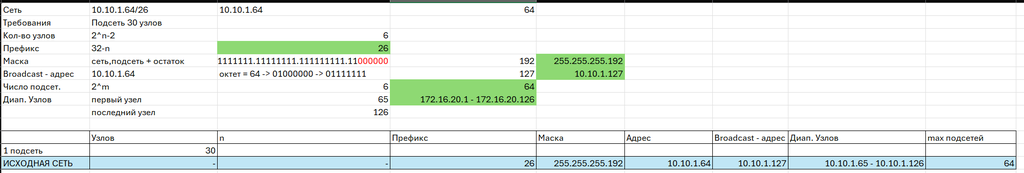

Расчёт исходной сети 10.10.1.64/26

## Расчёт выделенной подсети на 30 узлов

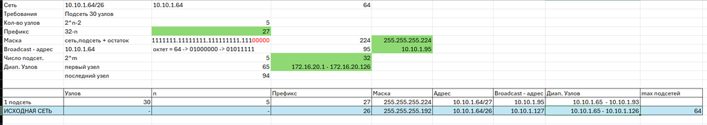

Расчёт выделенной подсети на 30 узлов в сети 10.10.1.64/26

# IPv4. Задание 3. Сеть 10.10.1.0/26

## Расчёт исходной сети

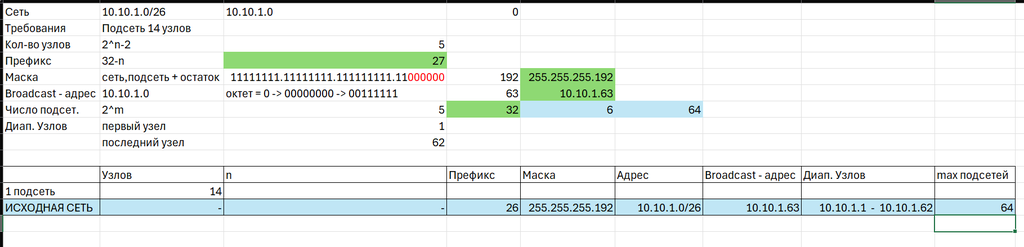

Расчёт исходной сети 10.10.1.0/26

## Расчёт выделенной подсети на 14 узлов

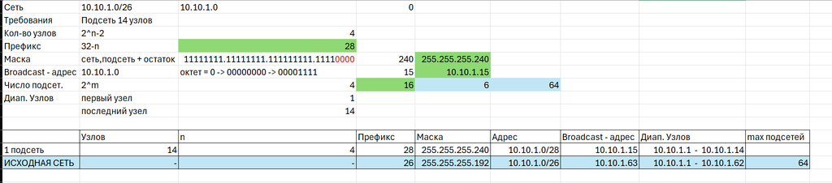

Расчёт выделенной подсети на 14 узлов в сети 10.10.1.0/26

# IPv6. Задание 1. Сеть 2001:db8:c0de::/48

## Характеристики и разбиение на 2 подсети двумя способами

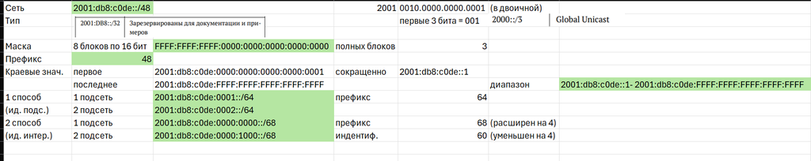

Характеристики сети 2001:db8:c0de::/48 и разбиение на 2 подсети двумя способами

# IPv6. Задание 2. Сеть 2a02:6b8::/64

## Характеристики и разбиение на 2 подсети двумя способами

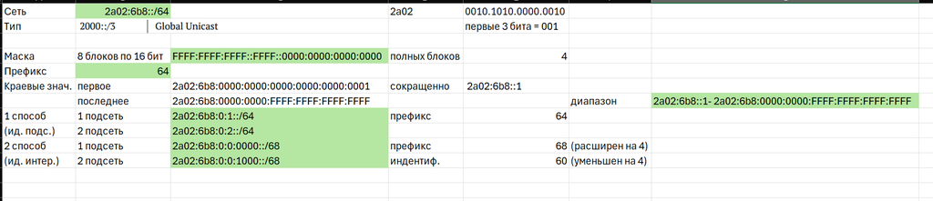

Характеристики сети 2a02:6b8::/64 и разбиение на 2 подсети двумя способами

# Выводы

Изучены принципы организации адресного пространства IPv4 и IPv6. Освоены методы расчёта масок, broadcast-адресов, диапазонов узлов, разбиения сетей на подсети с использованием VLSM для IPv4 и двумя способами для IPv6 (с использованием идентификатора подсети и с использованием идентификатора интерфейса). Получены практические навыки оформления результатов расчётов в табличном виде.